# Blog

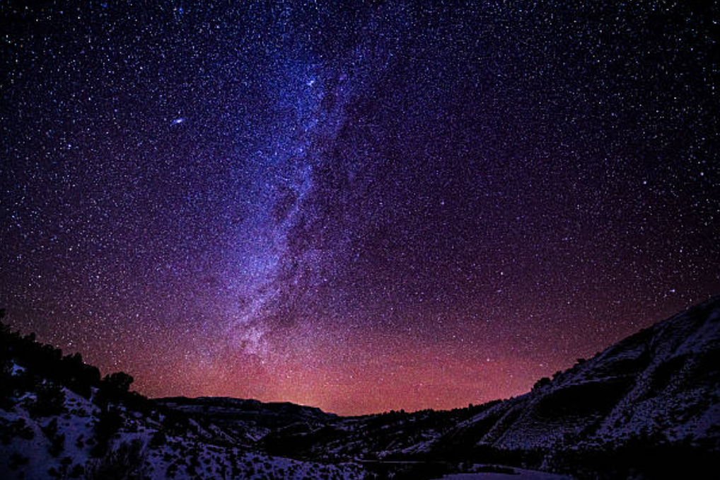

Statistics

Math

Jul 16, 2025

Md Allama Ikbal Sijan

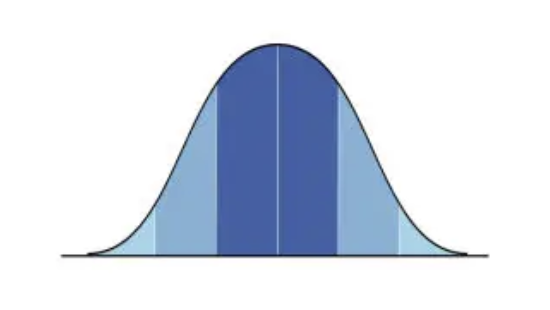

### The Central Limit Theorem: The Principle at the Heart of Statistics and Data Thinking

Statistics

Jun 25, 2025

Md Allama Ikbal Sijan

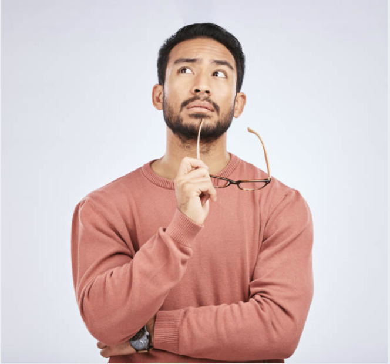

### So… What Do You Study Again? My Daily Struggle Explaining I/O Psychology to Strangers

I/O Psychology

Ever struggled to explain your field to someone outside your bubble? Welcome to my journey as an Industrial-Organizational psychologist—where I try to make sense of a often misunderstood field and my attempts at explaining it to others

Jun 12, 2025

Md Allama Ikbal Sijan

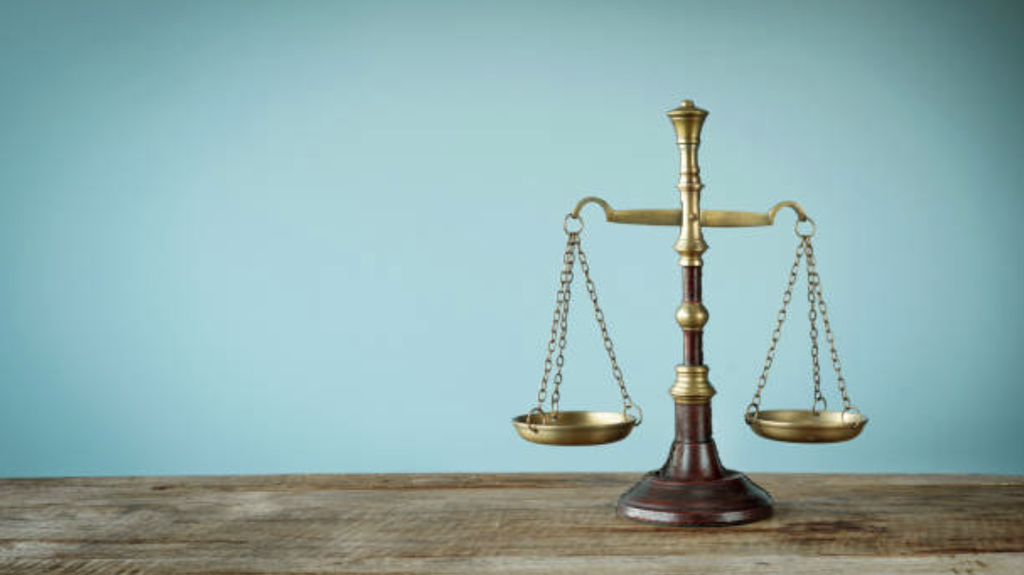

### Fairness at Work: More Than Objective System, It’s Perception

I/O Psychology

Growing up in a third world country, my sense of fairness was shaped by our history and upbringing. In this blog, I break down a concept that’s personal to me—the four dimensions of organizational justice and why they matter. Ultimately, I try to show why fairness must be both practiced and perceived to truly make a difference at work.

May 21, 2025

Md Allama Ikbal Sijan

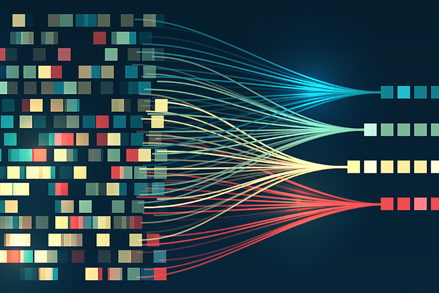

### Your Data Deserves Better: Understanding When to Use EFA or PCA

Psychometrics

Statistics

If you’ve ever opened SPSS -> Dimensionality Reduction -> Factor and wondered whether to choose EFA or PCA you’re not alone. These two methods sit side-by-side, look almost identical, and are often mixed up—even in published research. But they serve very different purposes, especially when we’re trying to understand psychological constructs. In this post, I’ll walk you through what those differences are and why they matter.

Apr 14, 2025

Md Allama Ikbal Sijan

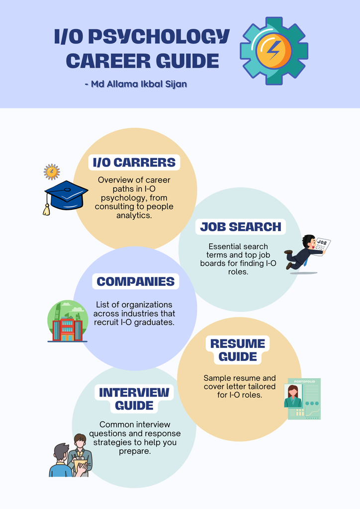

### I-O Psychology Career Resource Guide

Job Search

Career

Navigating a career in Industrial-Organizational Psychology can feel overwhelming, but the right resources can make all the difference. This guide provides a comprehensive overview of career paths, job search strategies, hiring companies, and application tips to help students confidently transition into the workforce.

Mar 10, 2025

Md Allama Ikbal Sijan

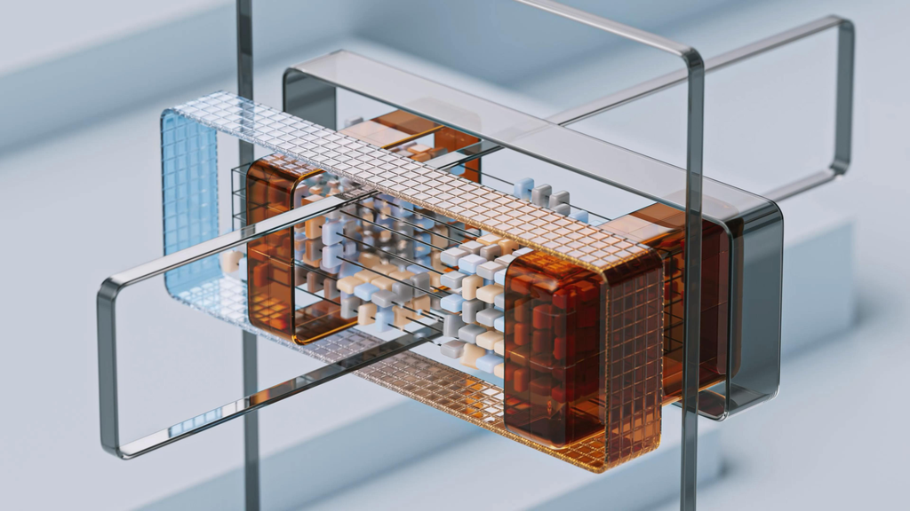

### What Are Data Structures? A Simple Introduction for Beginners

Data Science

Programming

Learn what data structures are, why they matter, and how they can improve the efficiency of your code. This blog introduces key concepts in an easy-to-understand way for those just starting their coding journey.

Dec 20, 2024

Md Allama Ikbal Sijan

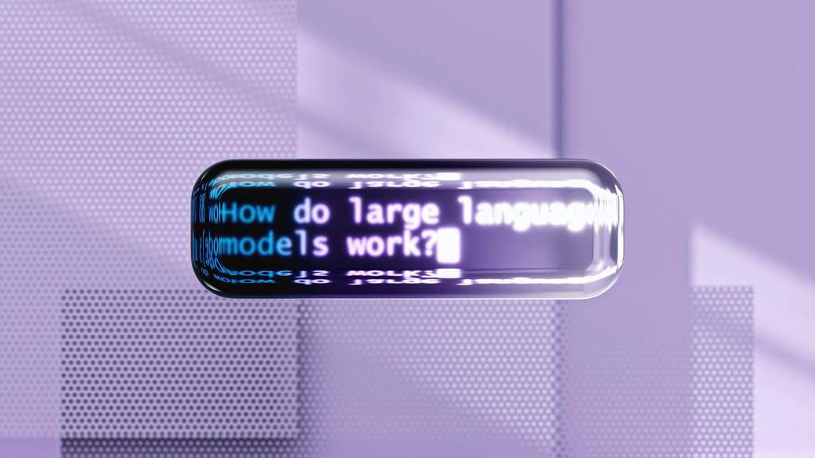

### From Text to Predictions: Using LLMs for NLP Tasks

LLM

NLP

This blog post walks you through using the transformers library to import pre-trained large language models (LLM) and its tokenizer. You’ll learn how to tokenize text, extract word embeddings from different hidden layers, and use these embeddings in machine learning models for prediction.

May 21, 2024

Md Allama Ikbal Sijan

### Making Training Stick: Insights from a Meta-Analysis on Training Transfer

Training

Transfer of training is a major challenge for organizations. Drawing on a seminal meta-analysis (Blume et al., 2010), this blog explores key factors that contribute to effective training transfer, providing insights to bridge the gap between training and on-the-job performance.

Mar 13, 2024

Md Allama Ikbal Sijan

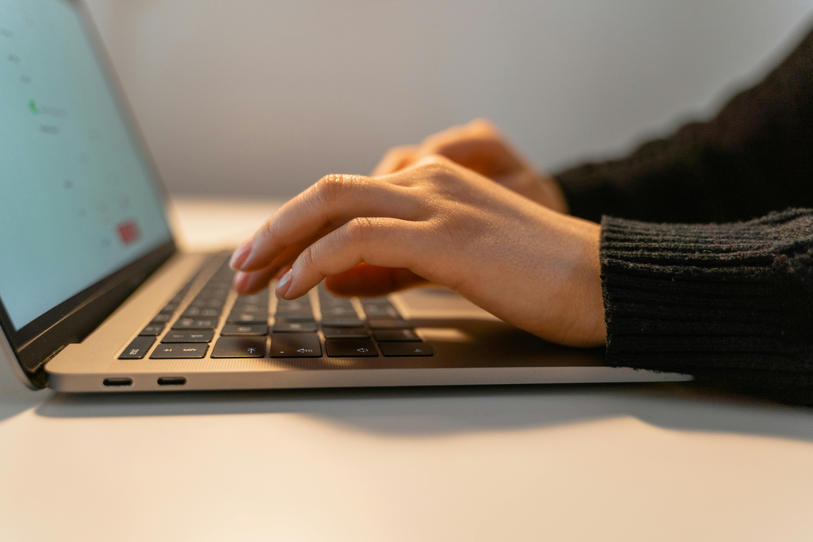

### R You Ready? An I/O Psychologist’s Guide to R & Rstudio

R

Workshop

My January 16, 2024 METRO workshop is now a blog post, covering the essential 20% of R syntax for 80% of data analysis tasks. This blog post is designed for both R beginners and those seeking a refresher.

Jan 15, 2024

Md Allama Ikbal Sijan